# numeric-python

- NumPy steht für **Num**erical **Py**thon und ist die Grundlage für wissenschaftliche Datenverarbeitung
- NumPy stellt viele optimierte algebraische Methoden zur Verfügung

Motivation:

- Im Praktikum (und allgemein in der Physik) werden Datenpunkte gemessen, die anschließend ausgewertet werden
- NumPy ist eine Python-Bibliothek, die den Umgang mit Datenpunkten enorm vereinfacht

Die Dokumentation ist [hier](https://numpy.org/doc/) zu finden.

```python
from IPython.display import Image
```

```python
%%javascript
$.getScript('https://kmahelona.github.io/ipython_notebook_goodies/ipython_notebook_toc.js')
```

# Grundlagen

```python
import numpy as np
```

- Grunddatentyp von NumPy ist das **n-dimensionale Array** (*numpy.ndarray*)
- NumPy Arrays speichern Werte *eines* Datentyps in einem zusammenhängenden Speicherbereich, wodurch mathematische Operationen auf allen Werten des Arrays effizienter sind
- Die Effizienz in den Berechnungen kommt durch NumPys Nutzung von optimiertem C/Cython Code statt purem Python Code

Hier sind einige erste Beispiele zur Nutzung dieser Arrays.

```python
x_arr = np.array([1, 2, 3, 4, 5])
```

```python
x_list = [1, 2, 3, 4, 5]
```

Arrays verhalten sich nicht wie Listen. Mathematischen Operationen werden komponentenweise auf die Elemente des Arrays angewendet.

```python
2 * x_arr
```

```
array([ 2,  4,  6,  8, 10])
```

```python
2 * x_list
```

```
[1, 2, 3, 4, 5, 1, 2, 3, 4, 5]
```

Fast alle mathematischen Operatoren aus Python funktionieren analog mit NumPy Arrays.

```python
x_arr**2
```

```
array([ 1,  4,  9, 16, 25])
```

```python
x_arr**x_arr
```

```
array([   1,    4,   27,  256, 3125])
```

**Achtung**: Bei besonderen Funktionen (cos, sin, exp, etc.) werden die NumPy Methoden benötigt, z.B. `np.cos()`!

```python
np.cos(x_arr)
```

```
array([ 0.54030231, -0.41614684, -0.9899925 , -0.65364362,  0.28366219])
```

```python
import math
# This doesn't work
math.cos(x_arr)
```

```
---------------------------------------------------------------------------
TypeError                                 Traceback (most recent call last)
Cell In[11], line 3
      1 import math
      2 # This doesn't work
----> 3 math.cos(x_arr)

TypeError: only length-1 arrays can be converted to Python scalars
```

Bei großen Datensätzen ist die *Laufzeit* relevant und NumPy ist einige Größenordnungen schneller:

```python
%%timeit
x_pure = [42] * 10000
x_pure2 = [x**2 for x in x_pure]
```

```
374 μs ± 8.1 μs per loop (mean ± std. dev. of 7 runs, 1,000 loops each)
```

```python
%%timeit
x = np.full(10000, 42)
x2 = x**2
```

```
6.42 μs ± 33.9 ns per loop (mean ± std. dev. of 7 runs, 100,000 loops each)
```

Selbstgeschriebene Funktionen, die nur für eine Zahl geschrieben wurden, funktionieren oft ohne Änderung mit NumPy Arrays.

```python
def poly(y):
    return y + 2 * y**2 - y**3


poly(np.pi)
```

```
-8.125475224531307
```

```python
poly(x_arr)
```

```
array([  2,   2,  -6, -28, -70])
```

Das erlaubt es einem unter anderem sehr leicht physikalische Formeln auf seine Datenpunkte anzuwenden.

Arrays können beliebige Dimension haben:

```python
# two-dimensional array
y = np.array(
    [
        [1, 2, 3],
        [4, 5, 6],
        [7, 8, 9],
    ]
)

# element-wise summation, like matrix summation
y + y
```

```
array([[ 2,  4,  6],
       [ 8, 10, 12],
       [14, 16, 18]])
```

Das erlaubt es z.B. eine ganze Tabelle von gleichen Datentypen als Array abzuspeichern.

Mit Arrays sind auch Matrixoperationen möglich:

```python
A = np.array(
    [
        [1, 1],
        [0, 1],
    ]
)
B = np.array(
    [
        [2, 0],
        [3, 4],
    ]
)

# element-wise product
element_wise_product = A * B
print("Elementweise Multiplikation:\n", element_wise_product)

# matrix product
matrix_product = A @ B
print("Matrix Multiplikation:\n", matrix_product)

# vector scalar product
one_dim_vectors = np.array([1, 2, 3]).T @ np.array([4, 5, 6])
print("Skalarprodukt von Vektoren:\n", one_dim_vectors)
```

```
Elementweise Multiplikation:
 [[2 0]
 [0 4]]
Matrix Multiplikation:
 [[5 4]
 [3 4]]
Skalarprodukt von Vektoren:
 32
```

# Eigenschaften von Arrays

NumPy-Arrays tragen neben den Daten noch zusätzliche Informationen über die Eigenschaften des Arrays.

Die *Dimension* eines Arrays kann mit der `ndim`-Funktion abgerufen werden. In NumPy werden die Dimensionen von 0 aufsteigend durchnummeriert. Wird über einzelne Dimensionen eines Arrays gesprochen, werden im NumPy Kontext die Bezeichnungen *Achse/Achsen (axis/axes)* verwendet. Die *Dimension* ist also die Anzahl aller *Achsen*.

Die `shape`-Funktion gibt in einem Tupel an, wie viele Elemente in jeder Dimension vorhanden sind.

Die Gesamtzahl der Elemente in einem Array können mit der `size`-Funktion abgefragt werden.

Der Datentyp eines Arrays muss innerhalb des Arrays der gleiche sein. Um den Datentyp eines Arrays abzufragen, gibt es die `dtype`-Funktion.

```python
a = np.array([1.5, 3.0, 4.2])
b = np.array(
    [
        [1, 2, 3],
        [4, 5, 6],
    ]
)

print(
    f"Array a: \n\t a.ndim   {a.ndim} \n\t a.shape  {a.shape} \n\t a.size   {a.size} \n\t a.dtype  {a.dtype}"
)
print(
    f"Array b: \n\t b.ndim   {b.ndim} \n\t b.shape  {b.shape} \n\t b.size   {b.size} \n\t b.dtype  {b.dtype}"
)
```

```
Array a:
	 a.ndim   1
	 a.shape  (3,)
	 a.size   3
	 a.dtype  float64
Array b:
	 b.ndim   2
	 b.shape  (2, 3)
	 b.size   6
	 b.dtype  int64
```

# Erstellen von Arrays

Es gibt viele nützliche Funktionen, die bei der Erstellung von Arrays helfen. Zum Verständnis der einzugebenden Argumente ist die [NumPy Dokumentation](https://numpy.org/doc/) zu empfehlen.

```python
np.zeros(10)
```

```
array([0., 0., 0., 0., 0., 0., 0., 0., 0., 0.])
```

```python
np.ones((5, 2))
```

```
array([[1., 1.],
       [1., 1.],
       [1., 1.],
       [1., 1.],
       [1., 1.]])
```

```python
np.linspace(0, 1, 11)
```

```
array([0. , 0.1, 0.2, 0.3, 0.4, 0.5, 0.6, 0.7, 0.8, 0.9, 1. ])
```

```python
# like range() for arrays:
np.arange(0, 10)
```

```
array([0, 1, 2, 3, 4, 5, 6, 7, 8, 9])
```

```python
np.logspace(-4, 5, 10)
```

```
array([1.e-04, 1.e-03, 1.e-02, 1.e-01, 1.e+00, 1.e+01, 1.e+02, 1.e+03,
       1.e+04, 1.e+05])
```

Aufgabe 1 kann bearbeitet werden.

# NumPy Indexing

NumPy erlaubt einem sehr bequem bestimmte Elemente aus einem Array auszuwählen und z.B. nur auf diesen Elementen Operationen auszuführen.

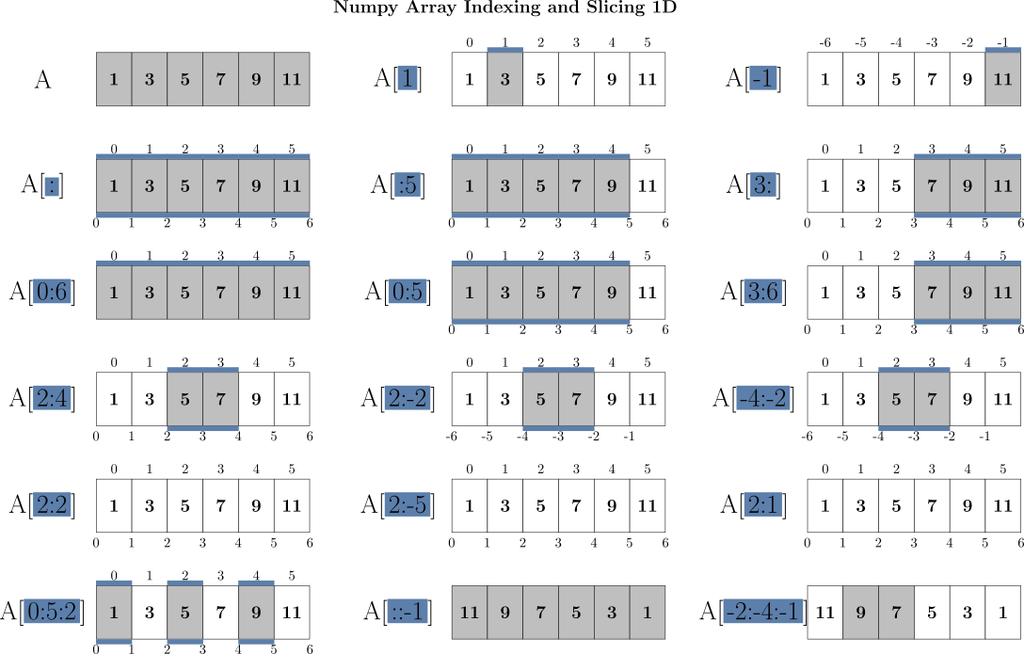

```python
Image(filename="images/Indexing1D.png")
```

```python
x = np.arange(0, 10)
print(x)

# like lists:
x[4]
```

```
[0 1 2 3 4 5 6 7 8 9]
```

```
np.int64(4)
```

```python
# all elements with indices ≥1 and <4:
x[1:4]
```

```
array([1, 2, 3])
```

```python
# negative indices count from the end
x[-1], x[-2]
```

```
(np.int64(9), np.int64(8))
```

```python
# combination:
x[3:-2]
```

```
array([3, 4, 5, 6, 7])
```

```python
# step size
x[::2]
```

```
array([0, 2, 4, 6, 8])
```

```python
# trick for reversal: negative step
x[::-1]
```

```
array([9, 8, 7, 6, 5, 4, 3, 2, 1, 0])
```

```python
y = np.array([x, x + 10, x + 20, x + 30])
y
```

```
array([[ 0,  1,  2,  3,  4,  5,  6,  7,  8,  9],
       [10, 11, 12, 13, 14, 15, 16, 17, 18, 19],
       [20, 21, 22, 23, 24, 25, 26, 27, 28, 29],
       [30, 31, 32, 33, 34, 35, 36, 37, 38, 39]])
```

```python
# comma between indices
y[3, 2:-1]
```

```
array([32, 33, 34, 35, 36, 37, 38])
```

```python
# only one index ⇒ one-dimensional array
y[2]
```

```
array([20, 21, 22, 23, 24, 25, 26, 27, 28, 29])
```

```python
# other axis: (`:` alone means the whole axis)
y[:, 3]
```

```
array([ 3, 13, 23, 33])
```

```python
# inspecting the number of elements per axis:
y.shape
```

```
(4, 10)
```

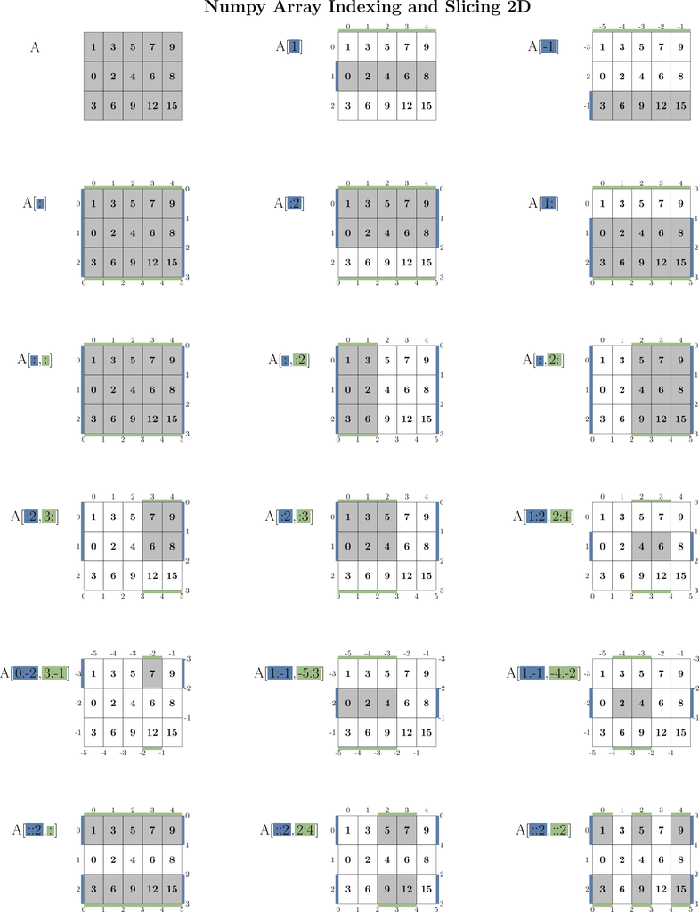

```python
Image(filename="images/Indexing2D.png")
```

Ausgewählten Elementen kann man auch direkt einen Wert zuweisen.

```python
y[:, 3] = 0
y
```

```
array([[ 0,  1,  2,  0,  4,  5,  6,  7,  8,  9],
       [10, 11, 12,  0, 14, 15, 16, 17, 18, 19],
       [20, 21, 22,  0, 24, 25, 26, 27, 28, 29],
       [30, 31, 32,  0, 34, 35, 36, 37, 38, 39]])
```

Man kann Indexing auch gleichzeitig auf der linken und rechten Seite benutzen.

```python
y[:, 0] = x[3:7]
y
```

```
array([[ 3,  1,  2,  0,  4,  5,  6,  7,  8,  9],
       [ 4, 11, 12,  0, 14, 15, 16, 17, 18, 19],
       [ 5, 21, 22,  0, 24, 25, 26, 27, 28, 29],
       [ 6, 31, 32,  0, 34, 35, 36, 37, 38, 39]])
```

Transponieren des Arrays kehrt die Reihenfolge der Indizes um.

```python
y
```

```
array([[ 3,  1,  2,  0,  4,  5,  6,  7,  8,  9],
       [ 4, 11, 12,  0, 14, 15, 16, 17, 18, 19],
       [ 5, 21, 22,  0, 24, 25, 26, 27, 28, 29],
       [ 6, 31, 32,  0, 34, 35, 36, 37, 38, 39]])
```

```python
y.T
```

```
array([[ 3,  4,  5,  6],
       [ 1, 11, 21, 31],
       [ 2, 12, 22, 32],
       [ 0,  0,  0,  0],
       [ 4, 14, 24, 34],
       [ 5, 15, 25, 35],
       [ 6, 16, 26, 36],
       [ 7, 17, 27, 37],
       [ 8, 18, 28, 38],
       [ 9, 19, 29, 39]])
```

```python
print(f"y \tShape: {y.shape} \ny.T \tShape: {y.T.shape}")
```

```
y 	Shape: (4, 10)
y.T 	Shape: (10, 4)
```

Aufgabe 2 kann bearbeitet werden.

# Masken

Oft will man Elemente auswählen, die eine oder mehrere Bedingungen erfüllen. Hierzu wird eine Maske (Array aus True/False-Werten) mit der gleichen Dimension erstellt. Die Maske kann in eckigen Klammern übergeben werden.

```python
a = np.linspace(0, 2, 11)
print(a)

# create a mask with the condition: element >= 1
mask = a >= 1
print(mask)

print(a[mask])
# do it in one step:
print(a[a >= 1])
```

```
[0.  0.2 0.4 0.6 0.8 1.  1.2 1.4 1.6 1.8 2. ]
[False False False False False  True  True  True  True  True  True]
[1.  1.2 1.4 1.6 1.8 2. ]
[1.  1.2 1.4 1.6 1.8 2. ]
```

# Reduzieren von Arrays

Viele Rechenoperationen reduzieren ein Array auf einen einzelnen Wert.

```python
y
```

```
array([[ 3,  1,  2,  0,  4,  5,  6,  7,  8,  9],
       [ 4, 11, 12,  0, 14, 15, 16, 17, 18, 19],
       [ 5, 21, 22,  0, 24, 25, 26, 27, 28, 29],
       [ 6, 31, 32,  0, 34, 35, 36, 37, 38, 39]])
```

So z.B. die Summe aller Elemente oder die Multiplikation.

```python
np.sum(y)
```

```
np.int64(666)
```

```python
np.prod(y)
```

```
np.int64(0)
```

```python
np.prod(y[y != 0])
```

```
np.int64(6652872369767448576)
```

Bei vielen solchen Methoden kann die Dimension mit angegeben werden.

```python
np.sum(y, axis=1)  # sum of each row
```

```
array([ 45, 126, 207, 288])
```

```python
np.prod(y, axis=0)  # multiplication of each column
```

```
array([   360,   7161,  16896,      0,  45696,  65625,  89856, 118881,
       153216, 193401])
```

Auch Mittelwert und Standardabweichung der Einträge kann einfach bestimmt werden.

```python
np.mean(y)
```

```
np.float64(16.65)
```

```python
np.std(y)
```

```
np.float64(12.590770429167549)
```

Oft wird im Praktikum aber nach der Unsicherheit des Mittelwerts gesucht.

```python
np.std(x, ddof=1) / np.sqrt(len(x))
```

```
np.float64(0.9574271077563381)
```

Dafür braucht man auch den Schätzer der Standardabweichung.

```python
np.std(x, ddof=1)
```

```
np.float64(3.0276503540974917)
```

Um die Differenzen zwischen benachbarten Elementen herauszufinden, kann die Funktion `np.diff()` genutzt werden.

```python
z = x**2
print("z:", z)

np.diff(z)
```

```
z: [ 0  1  4  9 16 25 36 49 64 81]
```

```
array([ 1,  3,  5,  7,  9, 11, 13, 15, 17])
```

# Input / Output

Um Datenpunkte aus einer Textdatei einzulesen wird die Funktion `np.genfromtxt()` genutzt. Sie gibt den Inhalt einer Textdatei als Array zurück.

Die Funktion, die Datenpunkte in eine Datei abspeichert, ist `np.savetxt()`.

```python
n = np.arange(11)
x = np.linspace(0, 1, 11)

np.savetxt("test.txt", [n, x])
```

Um den Inhalt der erstellten Datei zu öffnen, kann man analog zu Aufgabe `1-python/6-readwrite`, die `open`-Funktion benutzen.

```python
with open("test.txt") as f:
    print(f.read())
```

```
0.000000000000000000e+00 1.000000000000000000e+00 2.000000000000000000e+00 3.000000000000000000e+00 4.000000000000000000e+00 5.000000000000000000e+00 6.000000000000000000e+00 7.000000000000000000e+00 8.000000000000000000e+00 9.000000000000000000e+00 1.000000000000000000e+01
0.000000000000000000e+00 1.000000000000000056e-01 2.000000000000000111e-01 3.000000000000000444e-01 4.000000000000000222e-01 5.000000000000000000e-01 6.000000000000000888e-01 7.000000000000000666e-01 8.000000000000000444e-01 9.000000000000000222e-01 1.000000000000000000e+00
```

Für eine schönere Formatierung der Daten kann man auch `np.column_stack()` benutzen.

```python
data = np.array([n, x])

np.savetxt("test.txt", np.column_stack([n, x]))

with open("test.txt") as f:
    print(f.read())
```

```
0.000000000000000000e+00 0.000000000000000000e+00
1.000000000000000000e+00 1.000000000000000056e-01
2.000000000000000000e+00 2.000000000000000111e-01
3.000000000000000000e+00 3.000000000000000444e-01
4.000000000000000000e+00 4.000000000000000222e-01
5.000000000000000000e+00 5.000000000000000000e-01
6.000000000000000000e+00 6.000000000000000888e-01
7.000000000000000000e+00 7.000000000000000666e-01
8.000000000000000000e+00 8.000000000000000444e-01
9.000000000000000000e+00 9.000000000000000222e-01
1.000000000000000000e+01 1.000000000000000000e+00
```

Am besten sollte aber auch immer erklären werden, was abspeichert wird:

```python
n = np.arange(11)
x = np.linspace(0, 1, 11)

# header schreibt eine Kommentarzeile in die erste Zeile der Datei
np.savetxt("test.txt", np.column_stack([n, x]), header="n x")
with open("test.txt") as f:
    print(f.read())
```

```
# n x
0.000000000000000000e+00 0.000000000000000000e+00
1.000000000000000000e+00 1.000000000000000056e-01
2.000000000000000000e+00 2.000000000000000111e-01
3.000000000000000000e+00 3.000000000000000444e-01
4.000000000000000000e+00 4.000000000000000222e-01
5.000000000000000000e+00 5.000000000000000000e-01
6.000000000000000000e+00 6.000000000000000888e-01
7.000000000000000000e+00 7.000000000000000666e-01
8.000000000000000000e+00 8.000000000000000444e-01
9.000000000000000000e+00 9.000000000000000222e-01
1.000000000000000000e+01 1.000000000000000000e+00
```

```python
a, b = np.genfromtxt("test.txt", unpack=True)
a, b
```

```
(array([ 0.,  1.,  2.,  3.,  4.,  5.,  6.,  7.,  8.,  9., 10.]),
 array([0. , 0.1, 0.2, 0.3, 0.4, 0.5, 0.6, 0.7, 0.8, 0.9, 1. ]))
```

Um die Datentypen beim Speichern zu erhalten, muss das Keyword Argument `fmt`, wie im folgenden Beispiel gezeigt, angegeben werden.

```python
np.savetxt(
    "test.txt",
    np.column_stack([n, x]),
    fmt=["%d", "%.4f"],  # first column integer, second 4 digits float
    delimiter=",",
    header="n,x",
)
```

```python
data = np.genfromtxt(
    "test.txt",
    dtype=None,  # guess data types
    delimiter=",",
    names=True,
)
```

Das resultierende Array `data` ist besonders, da es ein sogenanntes `structured array` ist. Dies ist ein NumPy Array, in dem quasi mehrere Arrays in einem abgespeichert sind. Die einzelnen Arrays werden in der Dokumentation `fields` genannt und haben jeweils einen zugeordneten Namen und einen Datentyp.

```python
data
```

```
array([( 0, 0. ), ( 1, 0.1), ( 2, 0.2), ( 3, 0.3), ( 4, 0.4), ( 5, 0.5),
       ( 6, 0.6), ( 7, 0.7), ( 8, 0.8), ( 9, 0.9), (10, 1. )],
      dtype=[('n', '<i8'), ('x', '<f8')])
```

```python
data["n"], data.shape, data.dtype
```

```
(array([ 0,  1,  2,  3,  4,  5,  6,  7,  8,  9, 10]),
 (11,),
 dtype([('n', '<i8'), ('x', '<f8')]))
```

Aufgaben 3, 4 und 5 können bearbeitet werden.